# Benefit-Risk Profile of Drugs

**Main Plot**

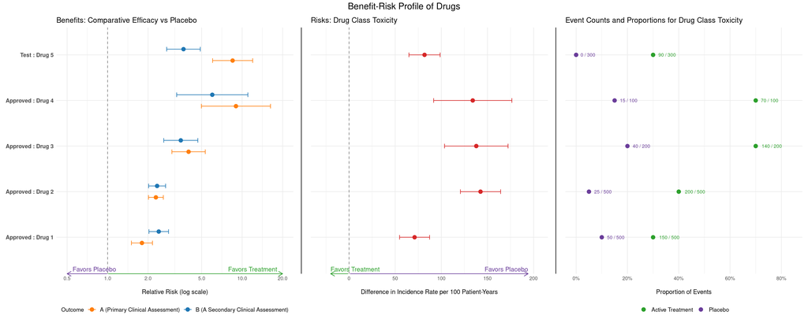

**Key Messaging**

### Efficacy Comparison (Left Panel)

- Drugs with data points further to the right are more effective compared to placebo.
- The spread of data points for each drug shows efficacy across different clinical assessments.
- Longer horizontal error bars indicate less certainty in the efficacy estimate.
- The purple arrow on the left indicates “Favors Placebo,” while the green arrow on the right indicates “Favors Treatment.”

### Risk Assessment (Middle Panel)

- Data points further to the right indicate higher toxicity risk.
- The difference in incidence rate per 100 patient-years provides a standardized measure of risk magnitude.
- Horizontal error bars show the uncertainty in the risk estimates.
- The green arrow on the left now indicates “Favors Treatment,” while the purple arrow on the right indicates “Favors Placebo.”

### Event Counts and Proportions (Right Panel)

- This panel shows the actual event counts and proportions for drug class toxicity.
- Purple dots represent placebo group data, while green dots represent active treatment group data.
- The proportions are visualized on a percentage scale for easy comparison.
- Actual event counts (n/N) are displayed next to each data point for precise information.

### Benefit-Risk Trade-off

- By comparing a drug’s position across all three panels, one can assess its overall profile.
- Ideal drugs would be far right in the left panel (high efficacy), far left in the middle panel (low toxicity), and have lower proportions of events in the right panel.
- The uncertainty in both benefit and risk estimates should be considered when making comparisons.

### Comparative Analysis

- The alignment of drugs across all three panels allows for easy comparison between different drugs.
- It’s possible to identify drugs that offer the best balance of high efficacy, low toxicity, and favorable event proportions.

### Decision Support

- This visualization supports informed decision-making in drug development and regulatory processes.
- It allows stakeholders to quickly grasp the overall benefit-risk profile of each drug in the portfolio, along with the actual event data.

### Uncertainty and Variability

- The error bars in the left and middle panels highlight the level of certainty in the efficacy and risk estimates.
- Different outcomes for the same drug in the efficacy panel show how efficacy can vary across different clinical assessments.
- The event counts in the right panel provide context for interpreting these uncertainties and variabilities.

### Standardized Comparison

- Using relative risk for efficacy, difference in incidence rate for risk, and actual proportions for events allows for a comprehensive and standardized comparison across drugs.
- The log scale for relative risk in the efficacy panel helps to visualize both small and large effects.

### Color Coding

- Consistent color coding across all three panels enhances interpretability:
  - Purple consistently represents placebo or outcomes favoring placebo.
  - Green consistently represents active treatment or outcomes favoring treatment.
- This color scheme helps in quickly identifying which group (placebo or active treatment) is favored in each aspect of the analysis.

### Comprehensive View

- The three-panel design provides a comprehensive view of drug performance:
  1. Efficacy compared to placebo
  2. Risk of toxicity
  3. Actual event counts and proportions
- This allows for a nuanced understanding of each drug’s performance across multiple dimensions.

**Code**

```r
# Load required libraries
library(ggplot2)
library(dplyr)
library(tidyr)
library(patchwork)
library(RColorBrewer)
library(readxl)
library(purrr)

# Read in data
brdata <- read_excel(paste0(here(), "/202503/brdata.xlsx"), sheet = "brdata")

# Rename columns based on the description tab
brdata <-  brdata %>%
  rename(
    Drug = Trt1,
    Placebo = Trt2,
    nSub1 = nSub1,
    N1 = N1,
    Prop1 = Prop1,
    nSub2 = nSub2,
    N2 = N2,
    Prop2 = Prop2,
    Diff_IncRate_LowerCI = Diff_IncRate_LowerCI,
    Diff_IncRate_UpperCI = Diff_IncRate_UpperCI,
    RelRisk_LowerCI = RelRisk_LowerCI,
    RelRisk_UpperCI = RelRisk_UpperCI
  )

# Convert relevant columns to numeric
numeric_cols <-  c("IncRate1", "IncRate2", "Diff_IncRate_LowerCI", "Diff_IncRate_UpperCI", "RelRisk_LowerCI", "RelRisk_UpperCI", "Prop1", "Prop2")

conversion_issues <- character(0)
brdata[numeric_cols] <- lapply(numeric_cols, function(col) {
  result <- tryCatch({
    as.numeric(gsub(",", "", as.character(brdata[[col]])))
  }, warning = function(w) {
    conversion_issues <<- c(conversion_issues, paste("Warning in", col, ":", conditionMessage(w)))
    as.numeric(gsub(",", "", as.character(brdata[[col]])))
  })
  result
})

if (length(conversion_issues) > 0) {
  cat("Conversion issues occurred:\n")
  cat(paste(conversion_issues, collapse = "\n"))
}

# Check for any remaining non-numeric values
non_numeric <-  sapply(brdata[numeric_cols], function(x) sum(is.na(x)))
print(non_numeric)

# Derive Diff_IncRate and RelRisk
brdata <- brdata %>%
  mutate(
    Diff_IncRate = IncRate1 - IncRate2,
    RelRisk = Prop1 / Prop2,
    Drug = paste(Drug_Status, ":", Drug) # Concatenate Drug_Status with Drug
  )

# Filter data for benefit and risk plots
benefit_data <-  brdata %>%
  filter(Factor == "Benefit", Grouped_Outcome %in% c("Clinical Assessment"), Filter == "None") %>%
  mutate(Drug = factor(Drug, levels = rev(unique(Drug))))

risk_data <-  brdata %>%
  filter(Factor == "Risk", Grouped_Outcome %in% c("Drug Class Toxicity"), Filter == "None") %>%
  mutate(Drug = factor(Drug, levels = rev(unique(Drug))))

# Define color palettes
benefit_colors <-  c("#FF7F0E", "#1F77B4") # Orange and Blue (complementary) for main benefit plot
active_color <- "#2CA02C" # Darker Green for Active Treatment (arrows and annotations)
placebo_color <- "#6A3D9A" # Darker Purple for Placebo (arrows and annotations)
risk_color <- "#D62728" # Red for risk plot

# Function to create benefit plot
create_benefit_plot <- function(data) {
  ggplot(data, aes(x = RelRisk, y = Drug, color = Outcome)) +
    geom_point(position = position_dodge(width = 0.5), size = 3) +
    geom_errorbarh(
      aes(xmin = RelRisk_LowerCI, xmax = RelRisk_UpperCI),
      position = position_dodge(width = 0.5),
      height = 0.2
    ) +
    geom_vline(xintercept = 1, linetype = "dashed", color = "gray50") +
    scale_x_log10(limits = c(0.5, 20), breaks = c(0.5, 1, 2, 5, 10, 20)) +
    scale_color_manual(values = benefit_colors) +
    labs(
      title = "Benefits: Comparative Efficacy vs Placebo",
      x = "\nRelative Risk (log scale)",
      y = NULL
    ) +
    theme_minimal() +
    theme(
      legend.position = "bottom",
      plot.margin = margin(b = 20),
      axis.text.y = element_text(face = "bold", size = 10),
      legend.text = element_text(size = 10),
      legend.title = element_text(size = 10)
    ) +
    coord_cartesian(clip = "off")
}

# Function to create risk plot
create_risk_plot <- function(data) {
  ggplot(data, aes(y = Drug)) +
    geom_point(aes(x = Diff_IncRate), size = 3, color = risk_color) +
    geom_errorbarh(
      aes(xmin = Diff_IncRate_LowerCI, xmax = Diff_IncRate_UpperCI),
      height = 0.1,
      linewidth = 0.5,
      color = risk_color
    ) +
    geom_vline(xintercept = 0, linetype = "dashed", color = "gray50") +
    scale_x_continuous(
      limits = c(
        min(data$Diff_IncRate_LowerCI, -20),
        max(data$Diff_IncRate_UpperCI) * 1.1
      ),
      expand = expansion(mult = c(0.1, 0.1))
    ) +
    labs(
      title = "Risks: Drug Class Toxicity",
      x = "\nDifference in Incidence Rate per 100 Patient-Years",
      y = NULL
    ) +
    theme_minimal() +
    theme(
      legend.position = "none",
      plot.margin = margin(b = 20),
      axis.text.y = element_text(face = "bold", size = 10)
    ) +
    coord_cartesian(clip = "off")
}

# Function to create count plot
create_count_plot <- function(data) {
  count_data <- data %>%
    select(Drug, nSub1, N1, Prop1, nSub2, N2, Prop2) %>%
    pivot_longer(
      cols = c(Prop1, Prop2),
      names_to = "Group",
      values_to = "Proportion"
    ) %>%
    mutate(
      Group = ifelse(Group == "Prop1", "Active Treatment", "Placebo"),
      Count = ifelse(
        Group == "Active Treatment",
        paste(nSub1, "/", N1),
        paste(nSub2, "/", N2)
      )
    )

  ggplot(count_data, aes(x = Proportion, y = Drug, color = Group)) +
    geom_point(size = 3) +
    geom_text(
      aes(label = Count),
      hjust = -0.3,
      vjust = 0.5,
      size = 3,
      show.legend = FALSE
    ) +
    scale_x_continuous(
      limits = c(0, max(count_data$Proportion) * 1.2),
      labels = scales::percent
    ) +
    scale_color_manual(
      values = setNames(
        c(active_color, placebo_color),
        c("Active Treatment", "Placebo")
      )
    ) +
    labs(
      title = "Event Counts and Proportions for Drug Class Toxicity",
      x = "\nProportion of Events",
      y = NULL
    ) +
    theme_minimal() +
    theme(
      legend.position = "bottom",
      axis.text.y = element_text(face = "bold", size = 10),
      legend.text = element_text(size = 10),
      legend.title = element_text(size = 10)
    ) +
    guides(color = guide_legend(title = NULL))
}

# Function to remove y-axis
remove_y_axis <- function(p) {
  p +
    theme(
      axis.text.y = element_blank(),
      axis.ticks.y = element_blank(),
      axis.title.y = element_blank()
    )
}

# Function to adjust y-axis
adjust_y_axis <- function(p, data) {
  p + scale_y_discrete(limits = unique(data$Drug))
}

# Function to add arrows and labels
add_arrows_and_labels <- function(
    p,
    x_left,
    x_right,
    y_pos,
    label_left,
    label_right,
    break_point,
    is_log_scale = FALSE,
    transparent = FALSE,
    reverse_colors = FALSE
) {
  text_offset <- if (is_log_scale) 0.1 else 0.05 * (x_right - x_left)

  if (is_log_scale) {
    gap <- 0.01 # Fixed small gap for log scale
    left_end <- break_point / (1 + gap)
    right_start <- break_point * (1 + gap)
  } else {
    gap <- 0.005 * (x_right - x_left)
    left_end <- break_point - gap
    right_start <- break_point + gap
  }

  if (reverse_colors) {
    arrow_color_left <- if (transparent) alpha(active_color, 0) else
      active_color
    arrow_color_right <- if (transparent) alpha(placebo_color, 0) else
      placebo_color
    text_color_left <- active_color
    text_color_right <- placebo_color
  } else {
    arrow_color_left <- if (transparent) alpha(placebo_color, 0) else
      placebo_color
    arrow_color_right <- if (transparent) alpha(active_color, 0) else
      active_color
    text_color_left <- placebo_color
    text_color_right <- active_color
  }

  p +
    # Left arrow
    annotate(
      "segment",
      x = x_left,
      xend = left_end,
      y = y_pos,
      yend = y_pos,
      arrow = arrow(length = unit(0.3, "cm"), ends = "first"),
      color = arrow_color_left
    ) +
    # Right arrow
    annotate(
      "segment",
      x = right_start,
      xend = x_right,
      y = y_pos,
      yend = y_pos,
      arrow = arrow(length = unit(0.3, "cm"), ends = "last"),
      color = arrow_color_right
    ) +
    # Labels
    annotate(
      "text",
      x = x_left * (if (is_log_scale) 1.1 else 1),
      y = y_pos + 0.1,
      label = label_left,
      hjust = 0,
      color = text_color_left,
      size = 4
    ) +
    annotate(
      "text",
      x = x_right / (if (is_log_scale) 1.1 else 1),
      y = y_pos + 0.1,
      label = label_right,
      hjust = 1,
      color = text_color_right,
      size = 4
    )
}

# Create and modify plots
benefit_plot <-  create_benefit_plot(benefit_data) %>%
  add_arrows_and_labels(
    0.5,
    20,
    0.2,
    "Favors Placebo",
    "Favors Treatment",
    break_point = 1,
    is_log_scale = TRUE
  )

risk_plot <-  create_risk_plot(risk_data) %>%
  remove_y_axis() %>%
  add_arrows_and_labels(
    min(risk_data$Diff_IncRate_LowerCI, -20),
    max(risk_data$Diff_IncRate_UpperCI) * 1.1,
    0.2,
    "Favors Treatment",
    "Favors Placebo",
    break_point = 0,
    is_log_scale = FALSE,
    reverse_colors = TRUE
  )

count_plot <-  create_count_plot(risk_data) %>%
  remove_y_axis() %>%
  # Add phantom line and annotation for alignment (now transparent)
  add_arrows_and_labels(
    0,
    0,
    0.2,
    "",
    "",
    break_point = 0.5,
    is_log_scale = FALSE,
    transparent = TRUE
  ) +
  theme(
    plot.margin = margin(t = 20, r = 5.5, b = 5.5, l = 5.5, unit = "pt")
  )

# Adjust y-axis for all plots
plots <-  list(benefit_plot, risk_plot, count_plot) %>%
  map(~ adjust_y_axis(., benefit_data))

# Function to create a thin vertical line plot with padding
create_separator <- function() {
  ggplot() +
    geom_vline(xintercept = 0, color = "black", size = 0.5) +
    theme_void() +
    theme(
      plot.margin = margin(0, 10, 0, 10, "pt"),
      panel.border = element_rect(color = NA, fill = NA)
    )
}

# Create separator plots
separator1 <- create_separator()
separator2 <- create_separator()

# Combine the plots with separators
combined_plot <- (plots[[1]] | separator1 | plots[[2]] | separator2 | plots[[3]]) +
  plot_layout(ncol = 5, widths = c(1, 0.02, 1, 0.02, 1)) +
  plot_annotation(
    title = "Benefit-Risk Profile of Drugs",
    theme = theme(
      plot.title = element_text(hjust = 0.5, size = 16),
      plot.margin = margin(10, 10, 10, 10)
    )
  ) &
  theme(
    plot.margin = margin(5, 5, 5, 5),
    legend.text = element_text(size = 10),
    legend.title = element_text(size = 10)
  )

# Save the plot
ggsave(
  paste0(here(), "/202503/benefit_risk_plot_nn.png"),
  combined_plot,
  width = 20,
  height = 8,
  dpi = 300
)

# Print the combined plot
print(combined_plot)
```